# 03 CAM

**Class Activation Mapping (CAM)**

By Prof. Seungchul Lee  
http://iai.postech.ac.kr/  
Industrial AI Lab at POSTECH

Table of Contents

- Attention
- Visualizing and Understanding Convolutional Networks
- Source
  - Source paper from http://cnnlocalization.csail.mit.edu/
  - Source code from https://github.com/metalbubble/CAM

# 1. CNN with a fully connected layer

The conventional CNN can be conceptually divided into two parts. One part is feature extraction and the other is classification. In the feature extraction process, convolution is used to extract the features of the input data so that the classification can be performed well. The classification process classifies which group each input data belongs to by using the extracted features from the input data.

When we visually identify images, we do not look at the whole image; instead, we intuitively focus on the most important parts of the image. CNN learning is similar to the way humans focus. When its weights are optimized, the more important parts are given higher weights. But generally, we are not able to recognize this because the generic CNN goes through a fully connected layer and makes the features extracted by the convolution layer more abstract.

[figure not shown]

# 2. CAM: CNN with a global average pooling

- shed light on how it explicitly enables the convolutional neural network to have remarkable localization ability
- the heatmap is the class activation map, highlighting the importance of the image region to the prediction

The deep learning model is a black box model. When input data is received, a classification result of 1 or 0 is simply returned for the binary classification problem, without knowing how the classification results are derived. Meanwhile, The class activation map (CAM) is capable of interpreting the results of the classification. We can determine which parts of the image the model is focusing on. Through an analysis of which part of the image the model is focusing on, we are able to interpret which part of the image is considered important.

The class activation map (CAM) is a modified convolution layer. It directly highlights the important parts of the spatial grid of an image. As a result, we can see the emphasized parts of the model. The below figure describes the procedure for class activation mapping.

[figure not shown]

The feature maps of the last convolution layer can be interpreted as a collection of visual spatial locations focused on by the model. The CAM can be obtained by taking a linear sum of the features. They all have different weights and thus can obtain spatial locations according to various input images through a linear combination. For a given image, $f_k(x,y)$ represents the feature map of unit $k$ in the last convolution layer at spatial location $(x,y)$. For a given class $c$, the class score, $S_c$, is expressed as the following equation.

$$S_c = \sum_k \omega_k^c \sum_{x,y} f_k(x,y)= \sum_{x,y} \sum_k \omega_k^c \; f_k(x,y)$$

where $\omega_k^c$ the weight corresponding to class $c$ for unit $k$. The class activation map for class $c$ is denoted as $M_c$.

$$M_c(x,y) = \sum_k \omega_k^c \; f_k(x,y)$$

$M_c$ directly indicates the importance of the feature map at a spatial grid $(x,y)$ of the class $c$. Finally the output of the softmax for class $c$ is,

$$P_c = \frac{\exp\left(S_c\right)}{\sum_c \exp\left(S_c\right)}$$

In case of the CNN, the size of the feature map is reduced by the pooling layer. By simple up-sampling, it is possible to identify attention image regions for each label.

# 3. CAM with MNIST

```python
import numpy as np
import matplotlib.pyplot as plt
import tensorflow as tf
import cv2

from tensorflow.examples.tutorials.mnist import input_data
mnist = input_data.read_data_sets("MNIST_data/", one_hot = True)
```

```
Extracting MNIST_data/train-images-idx3-ubyte.gz
Extracting MNIST_data/train-labels-idx1-ubyte.gz
Extracting MNIST_data/t10k-images-idx3-ubyte.gz
Extracting MNIST_data/t10k-labels-idx1-ubyte.gz
```

```python
idx_7 = np.where(np.argmax(mnist.train.labels, axis=1)==7)
idx_9 = np.where(np.argmax(mnist.train.labels, axis=1)==9)
image_7 = mnist.train.images[idx_7]
image_9 = mnist.train.images[idx_9]
```

```python
def batch_maker(n_batch):
    image = []
    label = []
    for i in range(n_batch):
        label.append(np.eye(2)[np.random.randint(2)])
        if np.argmax(label[-1])==0:
            idx_rand = np.random.randint(len(idx_7[0]))
            image.append(image_7[idx_rand])
        else:
            idx_rand = np.random.randint(len(idx_9[0]))
            image.append(image_9[idx_rand])
    return np.array(image), np.array(label)
```

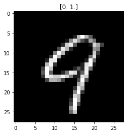

```python
image, label = batch_maker(2)
plt.imshow(image[0].reshape(28,28), 'gray')
plt.title(label[0])
plt.show()
```

```python
input_h = 28 # Input height
input_w = 28 # Input width
input_ch = 1 # Input channel : Gray scale
# (None, 28, 28, 1)

## First convolution layer
# Filter size
k1_h = 3
k1_w = 3
# the number of channels
k1_ch = 32
# Pooling size
p1_h = 2
p1_w = 2
# (None, 14, 14 ,32)

## Second convolution layer
# Filter size
k2_h = 3
k2_w = 3
# the number of channels
k2_ch = 64
# Pooling size
p2_h = 2
p2_w = 2
# (None, 7, 7 ,64)

n_output = 2
```

```python
weights = {
    'conv1' : tf.Variable(tf.random_normal([k1_h, k1_w, input_ch, k1_ch],stddev = 0.1)),
    'conv2' : tf.Variable(tf.random_normal([k2_h, k2_w, k1_ch, k2_ch],stddev = 0.1)),
    'output' : tf.Variable(tf.random_normal([k2_ch, n_output], stddev = 0.1))
}

biases = {
    'conv1' : tf.Variable(tf.random_normal([k1_ch], stddev = 0.1)),
    'conv2' : tf.Variable(tf.random_normal([k2_ch], stddev = 0.1))
}

x = tf.placeholder(tf.float32, [None, input_h, input_w, input_ch])
y = tf.placeholder(tf.float32, [None, n_output])
```

```python
# Define Network
def net(x, weights, biases):
    ## First convolution layer
    conv1 = tf.nn.conv2d(x, weights['conv1'],
                         strides= [1, 1, 1, 1],
                         padding = 'SAME')
    conv1 = tf.nn.relu(tf.add(conv1, biases['conv1']))
    maxp1 = tf.nn.max_pool(conv1,
                           ksize = [1, p1_h, p1_w, 1],
                           strides = [1, p1_h, p1_w, 1],
                           padding = 'VALID')

    ## Second convolution layer
    conv2 = tf.nn.conv2d(maxp1, weights['conv2'],
                         strides= [1, 1, 1, 1],
                         padding = 'SAME')
    conv2 = tf.nn.relu(tf.add(conv2, biases['conv2']))
    maxp2 = tf.nn.max_pool(conv2,
                           ksize = [1, p2_h, p2_w, 1],
                           strides = [1, p2_h, p2_w, 1],
                           padding = 'VALID')

    ## global average pooling
    temp = tf.reduce_mean(maxp2, (1,2))
    output = tf.matmul(temp, weights['output'])

    return maxp2, output
```

```python
LR = 1e-4

features, pred = net(x, weights, biases)
loss = tf.nn.softmax_cross_entropy_with_logits(labels = y, logits = pred)
loss = tf.reduce_mean(loss)

optm = tf.train.AdamOptimizer(LR).minimize(loss)

init = tf.global_variables_initializer()
```

```python
n_batch = 50
n_iter = 5000
n_prt = 250
```

```python
sess = tf.Session()
sess.run(init)
```

```python
for epoch in range(n_iter):
    train_x, train_y = batch_maker(n_batch)
    train_x = np.reshape(train_x, [-1, input_h, input_w, input_ch])
    sess.run(optm, feed_dict = {x: train_x, y :train_y})

    if epoch % n_prt ==0:
        cost = sess.run(loss, feed_dict = {x:train_x, y: train_y})
        print("Iter : {0}\t| Cost : {1}".format(epoch, cost))
```

```
Iter : 0	| Cost : 0.715050220489502
Iter : 250	| Cost : 0.6864659786224365
Iter : 500	| Cost : 0.6740758419036865
Iter : 750	| Cost : 0.6384163498878479
Iter : 1000	| Cost : 0.5831050276756287
Iter : 1250	| Cost : 0.5078002214431763
Iter : 1500	| Cost : 0.41324543952941895
Iter : 1750	| Cost : 0.4336218237876892
Iter : 2000	| Cost : 0.32014086842536926
Iter : 2250	| Cost : 0.36277636885643005
Iter : 2500	| Cost : 0.3129401206970215
Iter : 2750	| Cost : 0.2566772401332855
Iter : 3000	| Cost : 0.2680301368236542
Iter : 3250	| Cost : 0.18940338492393494
Iter : 3500	| Cost : 0.18554212152957916
Iter : 3750	| Cost : 0.25944221019744873
Iter : 4000	| Cost : 0.2531479001045227
Iter : 4250	| Cost : 0.11610589176416397
Iter : 4500	| Cost : 0.24890440702438354
Iter : 4750	| Cost : 0.17600375413894653
```

```python
test_x, test_y = batch_maker(100)

test_x = np.reshape(test_x, [-1, input_h, input_w, input_ch])
test_y = np.array(test_y)

my_pred = sess.run(pred, feed_dict = {x: test_x})
my_pred = np.argmax(my_pred, axis = 1)

labels = np.argmax(test_y, axis = 1)

accr = np.mean(np.equal(my_pred, labels))
print("Accuracy : {0} %".format(accr*100))
```

```
Accuracy : 97.0 %
```

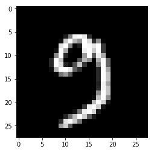

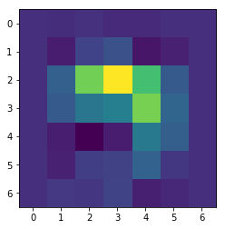

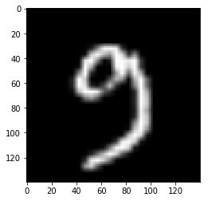

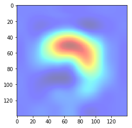

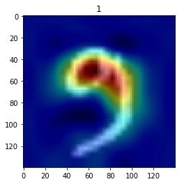

```python
test_x, test_y = batch_maker(1)
test_x = np.reshape(test_x, [-1, input_h, input_w, input_ch])
predict, feature, w = sess.run((pred, features, weights['output']), feed_dict = {x: test_x})
attention = np.matmul(feature, w)

plt.imshow(test_x.reshape(28,28), 'gray')
plt.show()
plt.imshow(attention[:, :, :, np.argmax(predict, axis = 1)].reshape(7,7))
plt.show()

larg_test_x = cv2.resize(test_x.reshape(28,28), (28*5, 28*5))
large_attention = cv2.resize(attention[:, :, :, np.argmax(predict, axis = 1)].reshape(7,7), (28*5, 28*5), interpolation = cv2.INTER_CUBIC)

plt.imshow(larg_test_x, 'gray')
plt.show()

plt.imshow(large_attention, 'jet', alpha = 0.5)
plt.show()

plt.imshow(larg_test_x, 'gray')
plt.imshow(large_attention, 'jet', alpha = 0.5)
plt.title(np.argmax(predict))
plt.show()
```

# 4. CAM to Video

```python
%%html
<center><iframe src="https://www.youtube.com/embed/TfCzQL-WbyI?rel=0"
width="560" height="315" frameborder="0" allowfullscreen></iframe></center>
```

[video not shown]

```python
%%javascript
$.getScript('https://kmahelona.github.io/ipython_notebook_goodies/ipython_notebook_toc.js')
```